# NHIS final project

KADGB

11/16/2019

## The haven package was utilized in R to view the stata dataset. The variables were then examined and changed to factor variables if appropriate.

```r
library(haven)
```

## The data were downloaded and cleaned in Stata before being imported to R for further analysis.The cleaning process in Stata entailed examining the variables, renaming them when appropriate, and removing missing data. A restricted dataset, including 42 out ofthe possible 132 variables was then imported into R.

```r
NHIS_Use <- read_dta("D:/SOC 8802/NHIS_Use.dta")
```

## Below is a view of the data in a table with 42 of the variables.

```r
NHIS_Use
```

```
## # A tibble: 30,309 x 42
##    fint_y_p fint_m_p   fmx rectype srvy_yr   hhx fm_size phoneuse fm_kids
##       <dbl>    <dbl> <dbl>   <dbl>   <dbl> <dbl>   <dbl>    <dbl>   <dbl>
##  1     2018        1     1      60    2018     1       1        3       0
##  2     2018        1     1      60    2018     4       3       NA       1
##  3     2018        2     1      60    2018     6       4       NA       2
##  4     2018        3     1      60    2018     8       3       NA       1
##  5     2018        2     1      60    2018     9       1       NA       0
##  6     2018        3     1      60    2018    10       4       NA       2
##  7     2018        1     1      60    2018    13       2       NA       1
##  8     2018        2     1      60    2018    15       2        3       0
##  9     2018        2     1      60    2018    17       3        1       0
## 10     2018        1     1      60    2018    18       3       NA       1
## # ... with 30,299 more rows, and 33 more variables: fdmedct <dbl>,
## #   fdmedyn <dbl>, fnmedct <dbl>, fnmedyn <dbl>, fslast <dbl>,
## #   fsless <dbl>, fshungry <dbl>, fchlmyn <dbl>, fspedyn <dbl>,
## #   flaadlyn <dbl>, fliadlyn <dbl>, fanylyn <dbl>, fchlmct <dbl>,
## #   fspedct <dbl>, fliadlct <dbl>, fanylct <dbl>, fhstatex <dbl>,
## #   fhstatvg <dbl>, fhstatg <dbl>, fhstatfr <dbl>, fhstatpr <dbl>,
## #   flaadlct <dbl>, fsnap <dbl>, rat_cat4 <dbl>, rat_cat5 <dbl>,
## #   spedEI <dbl+lbl>, numSEDEI <dbl>, snap <dbl+lbl>, nomed <dbl+lbl>,
## #   foodnl <dbl+lbl>, numNomed <dbl>, numADL <dbl>, numKids <dbl>
```

#view colums and rows

```r
dim(NHIS_Use)
```

```
## [1] 30309    42
```

```r
str(NHIS_Use)
```

```
## Classes 'tbl_df', 'tbl' and 'data.frame':    30309 obs. of  42 variables:
##  $ fint_y_p: num  2018 2018 2018 2018 2018 ...
##   ..- attr(*, "label")= chr "Year Interview Completed - Year"
##   ..- attr(*, "format.stata")= chr "%8.0g"
##  $ fint_m_p: num  1 1 2 3 2 3 1 2 2 1 ...
##   ..- attr(*, "label")= chr "Date of Interview - Month"
##   ..- attr(*, "format.stata")= chr "%8.0g"
##  $ fmx     : num  1 1 1 1 1 1 1 1 1 1 ...
##   ..- attr(*, "label")= chr "Family Number"
##   ..- attr(*, "format.stata")= chr "%8.0g"
##  $ rectype : num  60 60 60 60 60 60 60 60 60 60 ...
##   ..- attr(*, "label")= chr "File type identifier"
##   ..- attr(*, "format.stata")= chr "%8.0g"
##  $ srvy_yr : num  2018 2018 2018 2018 2018 ...
##   ..- attr(*, "label")= chr "Year of National Health Interview Survey"
##   ..- attr(*, "format.stata")= chr "%8.0g"
##  $ hhx     : num  1 4 6 8 9 10 13 15 17 18 ...
##   ..- attr(*, "label")= chr "Household Number"
##   ..- attr(*, "format.stata")= chr "%8.0g"
##  $ fm_size : num  1 3 4 3 1 4 2 2 3 3 ...
##   ..- attr(*, "label")= chr "Size of family"
##   ..- attr(*, "format.stata")= chr "%8.0g"
##  $ phoneuse: num  3 NA NA NA NA NA NA 3 1 NA ...
##   ..- attr(*, "label")= chr "Received calls cell/landline/both"
##   ..- attr(*, "format.stata")= chr "%8.0g"
##  $ fm_kids : num  0 1 2 1 0 2 1 0 0 1 ...
##   ..- attr(*, "label")= chr "# family members under 18 years of age"
##   ..- attr(*, "format.stata")= chr "%8.0g"
##  $ fdmedct : num  0 2 0 0 1 1 0 0 0 0 ...
##   ..- attr(*, "label")= chr "# of family members for whom medical care was delayed, 12m"
##   ..- attr(*, "format.stata")= chr "%8.0g"
##  $ fdmedyn : num  2 1 2 2 1 1 2 2 2 2 ...
##   ..- attr(*, "label")= chr "Any family member delay seeking medical care, 12m?"
##   ..- attr(*, "format.stata")= chr "%8.0g"
##  $ fnmedct : num  0 1 0 0 1 1 0 0 0 0 ...
##   ..- attr(*, "label")= chr "FNMEDCT"
##   ..- attr(*, "format.stata")= chr "%8.0g"
##  $ fnmedyn : num  2 1 2 2 1 1 2 2 2 2 ...
##   ..- attr(*, "label")= chr "FNMEDYN"
##   ..- attr(*, "format.stata")= chr "%8.0g"
```

[output cut: 80 more lines]

```
##   .. ..- attr(*, "names")= chr  "1.Yes" "2. No"
##  $ foodnl  : 'haven_labelled' num  3 2 3 3 1 3 3 3 3 3 ...
##   ..- attr(*, "label")= chr "cleaned food not last"
##   ..- attr(*, "format.stata")= chr "%9.0g"
##   ..- attr(*, "labels")= Named num  1 2
##   .. ..- attr(*, "names")= chr  "1.Yes" "2. No"
##  $ numNomed: num  0 1 0 0 1 1 0 0 0 0 ...
##   ..- attr(*, "label")= chr "number of family members no medical care"
##   ..- attr(*, "format.stata")= chr "%9.0g"
##  $ numADL  : num  0 0 0 0 1 0 0 0 0 0 ...
##   ..- attr(*, "label")= chr "number of family members ADL help"
##   ..- attr(*, "format.stata")= chr "%9.0g"
##  $ numKids : num  0 1 2 1 0 2 1 0 0 1 ...
##   ..- attr(*, "label")= chr "number of kids under 18"
##   ..- attr(*, "format.stata")= chr "%9.0g"
```

#View variable SPEDEI

```r
summary(NHIS_Use$spedEI)
```

```
##    Min. 1st Qu.  Median    Mean 3rd Qu.    Max.    NA's
##   1.000   2.000   2.000   1.868   2.000   2.000   21471
```

#View variable NOMED

```r
summary(NHIS_Use$nomed)
```

```
##    Min. 1st Qu.  Median    Mean 3rd Qu.    Max.    NA's
##   1.000   2.000   2.000   1.903   2.000   2.000      15
```

```r
levels(NHIS_Use$nomed)
```

#view variable numsedei

```r
summary(NHIS_Use$numSEDEI)
```

```
##    Min. 1st Qu.  Median    Mean 3rd Qu.    Max.    NA's
##   0.000   0.000   0.000   0.155   0.000   7.000   21457
```

```r
levels(NHIS_Use$numSEDEI)
```

```r
table(NHIS_Use$numSEDEI)
```

```
##
##    0    1    2    3    4    5    7
## 7686  996  140   25    3    1    1
```

```r
print(class(NHIS_Use$numSEDEI))
```

```
## [1] "numeric"
```

#Mean number of children receiving special education services or Early Intervention services in a household

```r
mean.SEDEI <- mean(NHIS_Use$numSEDEI, na.rm = TRUE)
mean.SEDEI
```

```
## [1] 0.1553321
```

#Mean Number of children per household

```r
mean.kids <-mean(NHIS_Use$numKids)
mean.kids
```

```
## [1] 0.5498367
```

```r
mean.ADL <-mean(NHIS_Use$numADL)
mean.ADL
```

```
## [1] 0.05288858
```

#Mean number of family members not seeking medical help due to costs

```r
mean.nomed <-mean(NHIS_Use$numNomed)
mean.nomed
```

```
## [1] 0.1146854
```

## We wanted to know if delaying medical care was strongly correlated with the number of kids in the family, number of children in the family who need help with ADL, and number of children receiving special education/early intervention. The rationale for correlating numNoMed with numSEDEI, numADL, and numKids is that families with more children, and chidren with disabilities face greater hardships not only in financial terms, but are also more likely to have time constrains due to caring for multiple children and/or children with disabilities.

```r
cor(NHIS_Use$numNomed, NHIS_Use$numKids, method ="pearson")
```

```
## [1] 0.0284983
```

```r
cor(NHIS_Use$numNomed, NHIS_Use$numADL, method = "pearson")
```

```
## [1] 0.06366678
```

```r
cor(NHIS_Use$numNomed, NHIS_Use$numSEDEI, use= "complete.obs", method ="pearson")
```

```
## [1] 0.0576574
```

## Plots of the correlations are generated below to aid with visual interpretation.

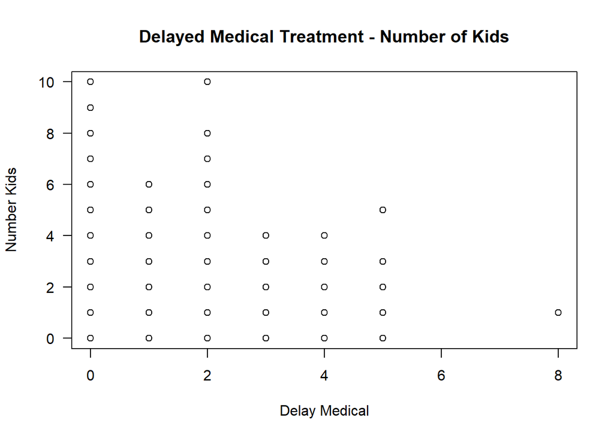

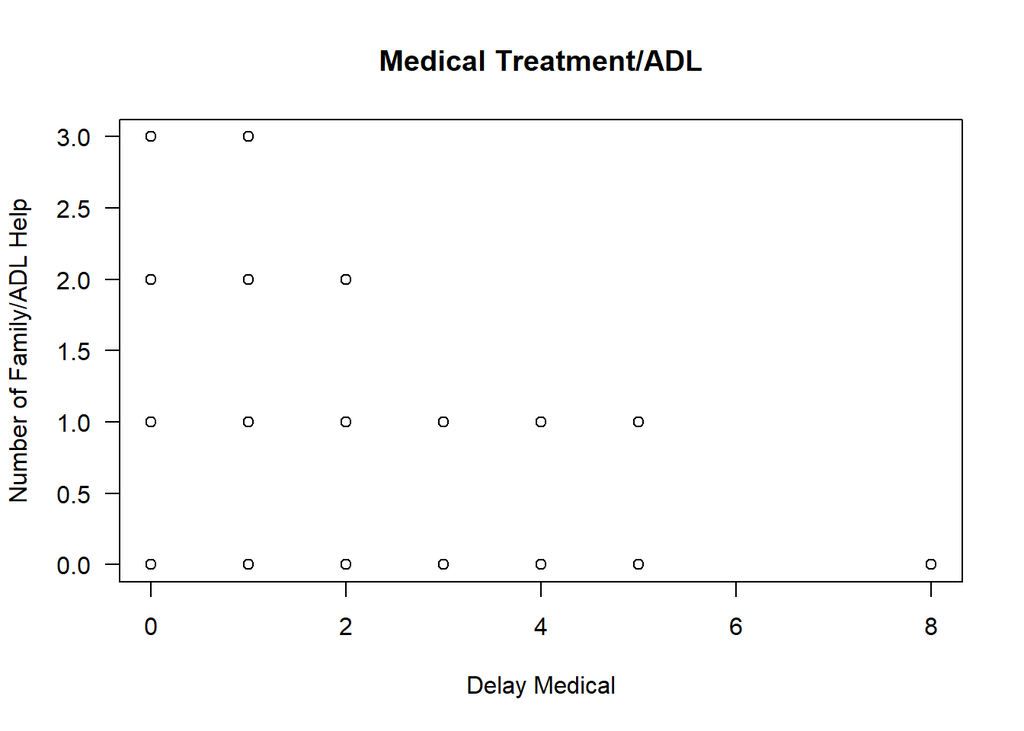

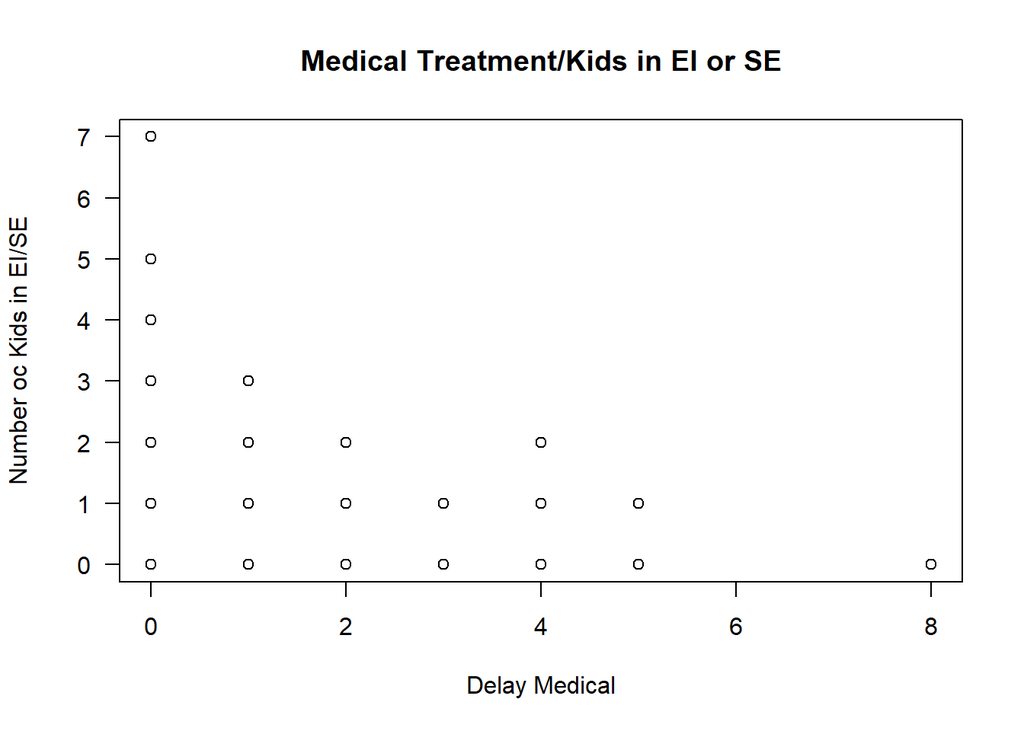